# Case Method 1

Ahmad Zaakiy Hidayat

2026-05-21

## Koneksi ke MySQL

Koneksi ke database MySQL dilakukan menggunakan package **DBI** dan **RMySQL** di R. Koneksi ini memungkinkan pengambilan data secara langsung dari database Sakila menggunakan query SQL, sehingga proses analisis dapat dilakukan secara efisien tanpa perlu memindahkan data secara manual.

## Deskripsi Data

Database yang digunakan dalam analisis ini adalah **Sakila**, yaitu database contoh yang disediakan oleh **MySQL** untuk keperluan pembelajaran dan latihan analisis data. Database ini merepresentasikan sistem penyewaan film (DVD rental) yang mencakup berbagai informasi terkait pelanggan, film, transaksi penyewaan, serta pembayaran.

Dataset ini bersifat relasional, yang terdiri dari beberapa tabel yang saling terhubung melalui *primary key* dan *foreign key*. Struktur ini memungkinkan dilakukan analisis yang lebih kompleks dengan menggabungkan beberapa tabel.

## Analisis Data

### 1. Total revenue

$$\text{Total Revenue} = \sum_{i=1}^{n} x_i$$
Keterangan:

- $x_i$ = jumlah pembayaran pada transaksi ke-i
- $n$ = jumlah seluruh transaksi

```r
query_total <- "
SELECT SUM(amount) AS total_revenue
FROM payment
"

total_rev <- dbGetQuery(con, query_total)
kable(total_rev)
```

| total_revenue |
| --- |
| 67406.56 |

Total revenue merupakan akumulasi seluruh transaksi pembayaran yang terjadi.

### 2. Rata-rata pendapatan per transaksi

$$\bar{x} = \frac{\sum_{i=1}^{n} x_i}{n}$$
Keterangan:

- $\bar{x}$ = rata-rata pendapatan per transaksi
- $x_i$ = jumlah pembayaran pada transaksi ke-i
- $n$ = jumlah seluruh transaksi

```r
query_avg <- "
SELECT AVG(amount) AS avg_revenue
FROM payment
"

avg_rev <- dbGetQuery(con, query_avg)
kable(avg_rev)
```

| avg_revenue |
| --- |
| 4.201356 |

```r
query <- "
SELECT c.name AS category, SUM(p.amount) AS revenue
FROM payment p
JOIN rental r ON p.rental_id = r.rental_id
JOIN inventory i ON r.inventory_id = i.inventory_id
JOIN film f ON i.film_id = f.film_id
JOIN film_category fc ON f.film_id = fc.film_id
JOIN category c ON fc.category_id = c.category_id
GROUP BY c.name
ORDER BY revenue DESC
"

data <- dbGetQuery(con, query)
kable(data)
```

| category | revenue |
| --- | --- |
| Sports | 5314.21 |
| Sci-Fi | 4756.98 |
| Animation | 4656.30 |
| Drama | 4587.39 |
| Comedy | 4383.58 |
| Action | 4375.85 |
| New | 4351.62 |
| Games | 4281.33 |
| Foreign | 4270.67 |
| Family | 4226.07 |
| Documentary | 4217.52 |
| Horror | 3722.54 |
| Children | 3655.55 |
| Classics | 3639.59 |
| Travel | 3549.64 |
| Music | 3417.72 |

### Visualisasi

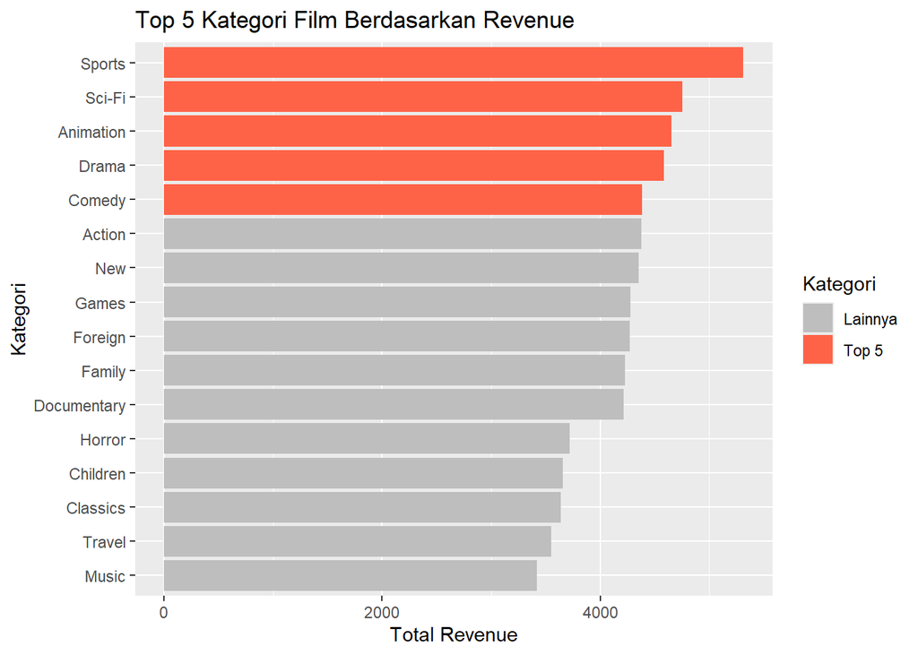

```r
# ambil top 5
top5 <- data %>%
  arrange(desc(revenue)) %>%
  slice(1:5)

# tandai top 5
data$top5 <- ifelse(data$category %in% top5$category, "Top 5", "Lainnya")

# plot
ggplot(data, aes(x = reorder(category, revenue), y = revenue, fill = top5)) +
  geom_bar(stat = "identity") +
  coord_flip() +
  scale_fill_manual(values = c("Top 5" = "tomato", "Lainnya" = "grey")) +
  labs(
    title = "Top 5 Kategori Film Berdasarkan Revenue",
    x = "Kategori",
    y = "Total Revenue",
    fill = "Kategori"
  )
```

Berdasarkan hasil visualisasi, kategori film dengan pendapatan tertinggi adalah kategori **Sports**. Hal ini menunjukkan bahwa kategori tersebut memiliki tingkat permintaan yang lebih tinggi dibandingkan kategori lainnya. Sebaliknya, kategori dengan pendapatan terendah adalah kategori **Music**, yang mengindikasikan rendahnya minat pelanggan terhadap kategori tersebut.

### 4. 10 Film yang memiliki popularitas tertinggi berdasarkan total rental

```r
query3 <- "
SELECT f.title, COUNT(r.rental_id) AS total_rental
FROM film f
JOIN inventory i ON f.film_id = i.film_id
JOIN rental r ON i.inventory_id = r.inventory_id
GROUP BY f.title
ORDER BY total_rental DESC
LIMIT 10
"

film_pop <- dbGetQuery(con, query3)
kable(film_pop)
```

| title | total_rental |
| --- | --- |
| BUCKET BROTHERHOOD | 34 |
| ROCKETEER MOTHER | 33 |
| RIDGEMONT SUBMARINE | 32 |
| GRIT CLOCKWORK | 32 |
| SCALAWAG DUCK | 32 |
| JUGGLER HARDLY | 32 |
| FORWARD TEMPLE | 32 |
| HOBBIT ALIEN | 31 |
| ROBBERS JOON | 31 |
| ZORRO ARK | 31 |

### Visualisasi

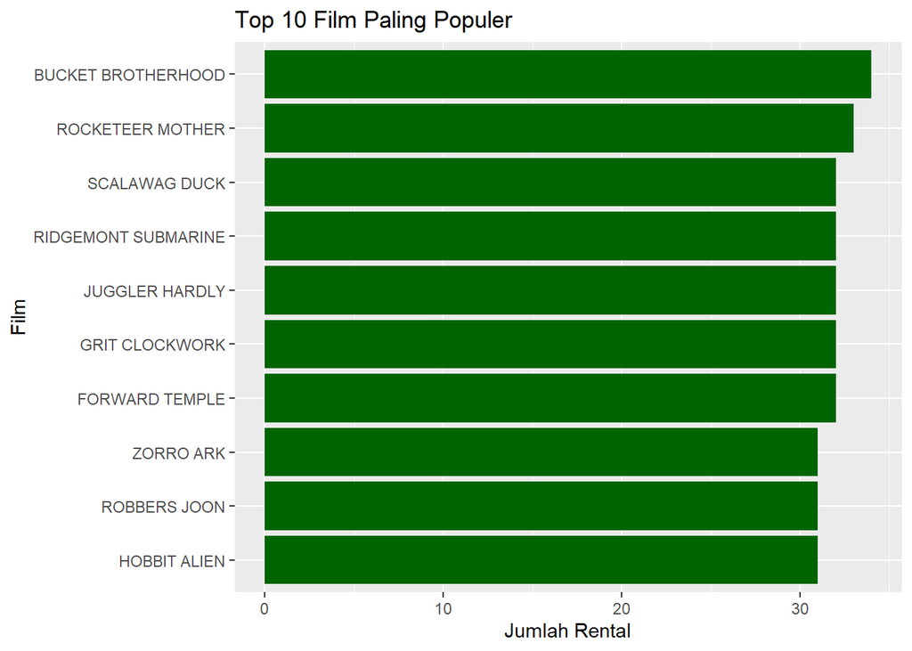

### 5. Perbandingan pendapatan antar toko

```r
query4 <- "
SELECT s.store_id, SUM(p.amount) AS revenue
FROM store s
JOIN staff st ON s.store_id = st.store_id
JOIN payment p ON st.staff_id = p.staff_id
GROUP BY s.store_id
"

store_rev <- dbGetQuery(con, query4)
kable(store_rev)
```

| store_id | revenue |
| --- | --- |
| 1 | 33482.50 |
| 2 | 33924.06 |

### Visualisasi

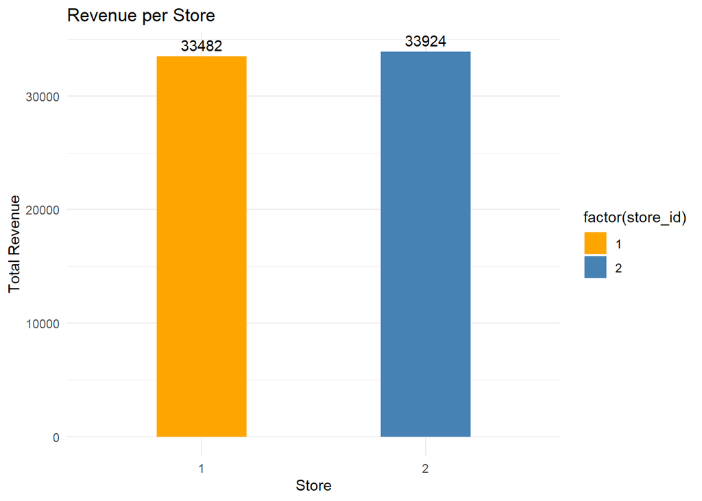

Berdasarkan hasil analisis, terdapat perbedaan pendapatan antara masing-masing store. Store dengan pendapatan lebih tinggi (Store 2) menunjukkan performa yang lebih baik dalam menghasilkan transaksi. Hal ini dapat dipengaruhi oleh lokasi, jumlah pelanggan, atau efektivitas operasional store tersebut.